# Exploratory Data Analysis

Hieu Phi Nguyen

August 14, 2021

# Checking data and missing value

We delete last 2 columns as suggestion of the author of Kaggle.

```r
pacman::p_load(tidyverse, psych, gridExtra, tseries, broom, PCAmixdata)
df <- as_tibble(read.csv('BankChurners.csv', header = T))
df <- df %>%
    select(-Naive_Bayes_Classifier_Attrition_Flag_Card_Category_Contacts_Count_12_mon_Dependent_count_Education_Level_Months_Inactive_12_mon_1, -Naive_Bayes_Classifier_Attrition_Flag_Card_Category_Contacts_Count_12_mon_Dependent_count_Education_Level_Months_Inactive_12_mon_2)
dim(df)
```

```
## [1] 10127    21
```

```r
sum(is.na(df))
```

```
## [1] 0
```

```r
table(df$Attrition_Flag)
```

```
##
## Attrited Customer Existing Customer
##              1627              8500
```

Data contains 10127 observations with 21 features. No missing value. Target distribution is kind of skewed with majority of Existing Customer (8500 customers - 84%), implying a severe imbalanced problem.

# Univariate

```r
glimpse(df)
```

```
## Rows: 10,127
## Columns: 21
## $ CLIENTNUM                <int> 768805383, 818770008, 713982108, 769911858, 709106358, 71306…
## $ Attrition_Flag           <chr> "Existing Customer", "Existing Customer", "Existing Customer…
## $ Customer_Age             <int> 45, 49, 51, 40, 40, 44, 51, 32, 37, 48, 42, 65, 56, 35, 57, …
## $ Gender                   <chr> "M", "F", "M", "F", "M", "M", "M", "M", "M", "M", "M", "M", …
## $ Dependent_count          <int> 3, 5, 3, 4, 3, 2, 4, 0, 3, 2, 5, 1, 1, 3, 2, 4, 4, 3, 1, 2, …
## $ Education_Level          <chr> "High School", "Graduate", "Graduate", "High School", "Unedu…
## $ Marital_Status           <chr> "Married", "Single", "Married", "Unknown", "Married", "Marri…
## $ Income_Category          <chr> "$60K - $80K", "Less than $40K", "$80K - $120K", "Less than …
## $ Card_Category            <chr> "Blue", "Blue", "Blue", "Blue", "Blue", "Blue", "Gold", "Sil…
## $ Months_on_book           <int> 39, 44, 36, 34, 21, 36, 46, 27, 36, 36, 31, 54, 36, 30, 48, …
## $ Total_Relationship_Count <int> 5, 6, 4, 3, 5, 3, 6, 2, 5, 6, 5, 6, 3, 5, 5, 5, 6, 4, 2, 6, …
## $ Months_Inactive_12_mon   <int> 1, 1, 1, 4, 1, 1, 1, 2, 2, 3, 3, 2, 6, 1, 2, 1, 2, 4, 2, 1, …
## $ Contacts_Count_12_mon    <int> 3, 2, 0, 1, 0, 2, 3, 2, 0, 3, 2, 3, 0, 3, 2, 2, 3, 1, 3, 2, …
## $ Credit_Limit             <dbl> 12691.0, 8256.0, 3418.0, 3313.0, 4716.0, 4010.0, 34516.0, 29…
## $ Total_Revolving_Bal      <int> 777, 864, 0, 2517, 0, 1247, 2264, 1396, 2517, 1677, 1467, 15…
## $ Avg_Open_To_Buy          <dbl> 11914.0, 7392.0, 3418.0, 796.0, 4716.0, 2763.0, 32252.0, 276…
## $ Total_Amt_Chng_Q4_Q1     <dbl> 1.335, 1.541, 2.594, 1.405, 2.175, 1.376, 1.975, 2.204, 3.35…
## $ Total_Trans_Amt          <int> 1144, 1291, 1887, 1171, 816, 1088, 1330, 1538, 1350, 1441, 1…
## $ Total_Trans_Ct           <int> 42, 33, 20, 20, 28, 24, 31, 36, 24, 32, 42, 26, 17, 33, 29, …
## $ Total_Ct_Chng_Q4_Q1      <dbl> 1.625, 3.714, 2.333, 2.333, 2.500, 0.846, 0.722, 0.714, 1.18…
## $ Avg_Utilization_Ratio    <dbl> 0.061, 0.105, 0.000, 0.760, 0.000, 0.311, 0.066, 0.048, 0.11…
```

```r
summary(df)
```

```
##    CLIENTNUM         Attrition_Flag      Customer_Age      Gender          Dependent_count
##  Min.   :708082083   Length:10127       Min.   :26.00   Length:10127       Min.   :0.000
##  1st Qu.:713036770   Class :character   1st Qu.:41.00   Class :character   1st Qu.:1.000
##  Median :717926358   Mode  :character   Median :46.00   Mode  :character   Median :2.000
##  Mean   :739177606                      Mean   :46.33                      Mean   :2.346
##  3rd Qu.:773143533                      3rd Qu.:52.00                      3rd Qu.:3.000
##  Max.   :828343083                      Max.   :73.00                      Max.   :5.000
##  Education_Level    Marital_Status     Income_Category    Card_Category      Months_on_book
##  Length:10127       Length:10127       Length:10127       Length:10127       Min.   :13.00
##  Class :character   Class :character   Class :character   Class :character   1st Qu.:31.00
##  Mode  :character   Mode  :character   Mode  :character   Mode  :character   Median :36.00
##                                                                              Mean   :35.93
##                                                                              3rd Qu.:40.00
##                                                                              Max.   :56.00
##  Total_Relationship_Count Months_Inactive_12_mon Contacts_Count_12_mon  Credit_Limit
##  Min.   :1.000            Min.   :0.000          Min.   :0.000         Min.   : 1438
##  1st Qu.:3.000            1st Qu.:2.000          1st Qu.:2.000         1st Qu.: 2555
##  Median :4.000            Median :2.000          Median :2.000         Median : 4549
##  Mean   :3.813            Mean   :2.341          Mean   :2.455         Mean   : 8632
##  3rd Qu.:5.000            3rd Qu.:3.000          3rd Qu.:3.000         3rd Qu.:11068
##  Max.   :6.000            Max.   :6.000          Max.   :6.000         Max.   :34516
##  Total_Revolving_Bal Avg_Open_To_Buy Total_Amt_Chng_Q4_Q1 Total_Trans_Amt Total_Trans_Ct
##  Min.   :   0        Min.   :    3   Min.   :0.0000       Min.   :  510   Min.   : 10.00
##  1st Qu.: 359        1st Qu.: 1324   1st Qu.:0.6310       1st Qu.: 2156   1st Qu.: 45.00
##  Median :1276        Median : 3474   Median :0.7360       Median : 3899   Median : 67.00
##  Mean   :1163        Mean   : 7469   Mean   :0.7599       Mean   : 4404   Mean   : 64.86
##  3rd Qu.:1784        3rd Qu.: 9859   3rd Qu.:0.8590       3rd Qu.: 4741   3rd Qu.: 81.00
##  Max.   :2517        Max.   :34516   Max.   :3.3970       Max.   :18484   Max.   :139.00
##  Total_Ct_Chng_Q4_Q1 Avg_Utilization_Ratio
##  Min.   :0.0000      Min.   :0.0000
##  1st Qu.:0.5820      1st Qu.:0.0230
##  Median :0.7020      Median :0.1760
##  Mean   :0.7122      Mean   :0.2749
##  3rd Qu.:0.8180      3rd Qu.:0.5030
##  Max.   :3.7140      Max.   :0.9990
```

There are no inaccurate data, e.g. customer age are ranged from 26 years old to 73 years old, which is legal in several countries. Also, we have 6 categorical variables.

## Categorical variables

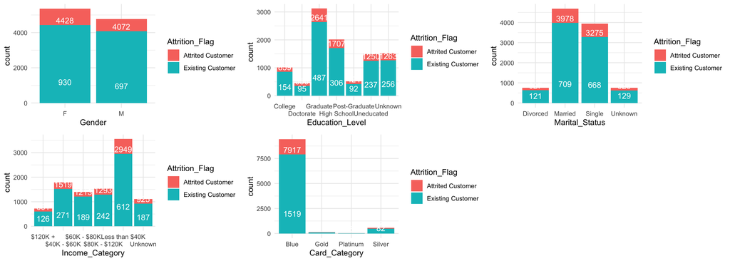

```r
p1 <- df %>%
  group_by(Attrition_Flag, Gender) %>%
  summarise(count = n()) %>%
  ggplot(aes(x = Gender, y = count, fill = Attrition_Flag)) +
    geom_histogram(stat = "identity") +
    geom_text(aes(label = count), vjust = -0.3, color = 'white') +
    theme_minimal()

p2 <- df %>%
  group_by(Attrition_Flag, Education_Level) %>%
  summarise(count = n()) %>%
  ggplot(aes(x = Education_Level, y = count, fill = Attrition_Flag)) +
    geom_histogram(stat = "identity") +
    geom_text(aes(label = count), vjust = -0.3, color = 'white') +
    scale_x_discrete(guide = guide_axis(n.dodge = 2)) +
    theme_minimal()

p3 <- df %>%
  group_by(Attrition_Flag, Marital_Status) %>%
  summarise(count = n()) %>%
  ggplot(aes(x = Marital_Status, y = count, fill = Attrition_Flag)) +
    geom_histogram(stat = "identity") +
    geom_text(aes(label = count), vjust = -0.3, color = 'white') +
    theme_minimal()

p4 <- df %>%
  group_by(Attrition_Flag, Income_Category) %>%
  summarise(count = n()) %>%
  ggplot(aes(x = Income_Category, y = count, fill = Attrition_Flag)) +
    geom_histogram(stat = "identity") +
    geom_text(aes(label = count), vjust = -0.3, color = 'white') +
    scale_x_discrete(guide = guide_axis(n.dodge = 2)) +
    theme_minimal()

p5 <- df %>%
  group_by(Attrition_Flag, Card_Category) %>%
  summarise(count = n()) %>%
  ggplot(aes(x = Card_Category, y = count, fill = Attrition_Flag)) +
    geom_histogram(stat = "identity") +
    geom_text(aes(label = count), vjust = -0.3, color = 'white') +
    theme_minimal()

grid.arrange(p1, p2, p3, p4, p5, nrow = 2)
```

Interestingly, we note that the among categorical variables the percentage of Attrited Customers seems to be fairly equal across all categories of all the Variables. Despite having a large imbalance in the proportions across the categories; the attrition however is quite similar. There seems to be no significant categorical variable that shows a strong indicator for Attrition. More formal test: [Chi-squared test](https://data-flair.training/blogs/chi-square-test-in-r/#:~:text=Chi%2DSquare%20test%20in%20R%20is%20a%20statistical%20method%20which,Green%2C%20Yes%2FNo%20etc.). Here H0: The two variables are independent and H1: The two variables relate to each other.

```r
dat <- data.frame(Variable = character(),ChiSq = numeric(), DF = numeric(), PVal = numeric())
for (name in names(df %>% select(where(is.character), - Attrition_Flag))){
  chiTest <- chisq.test(df$Attrition_Flag, df[[name]])
  dat <- rbind(dat, data.frame(Variable = name, ChiSq = chiTest$statistic, DF = chiTest$parameter, PVal = chiTest$p.value))
}
DT::datatable(dat, rownames = FALSE)
```

| Variable | ChiSq | DF | PVal |
| --- | --- | --- | --- |
| Gender | 13.8656137006373 | 1 | 0.000196358467173103 |
| Education_Level | 12.5112054048305 | 6 | 0.0514891314733663 |
| Marital_Status | 6.05609739672662 | 3 | 0.108912633948402 |
| Income_Category | 12.8322592747569 | 5 | 0.0250024257043906 |
| Card_Category | 2.23422670000468 | 3 | 0.525238279799476 |

With p-value less than 0.05, we reject the H0 for `Gender`,`Income_Category`.

## Continuous variables

```r
df %>%
  select(-where(is.character), -CLIENTNUM) %>%
  describe() %>%
  DT::datatable(options = list(scrollX = TRUE))
```

|  | vars | n | mean | sd | median | trimmed | mad | min | max | range | skew | kurtosis | se |
| --- | --- | --- | --- | --- | --- | --- | --- | --- | --- | --- | --- | --- | --- |
| Customer_Age | 1 | 10127 | 46.3259603041375 | 8.01681403254903 | 46 | 46.3504874737751 | 8.8956 | 26 | 73 | 47 | -0.0335950618970852 | -0.289605212015481 | 0.0796638707507953 |
| Dependent_count | 2 | 10127 | 2.34620321911721 | 1.29890834890379 | 2 | 2.36702455880538 | 1.4826 | 0 | 5 | 5 | -0.0208193667120272 | -0.683729403543614 | 0.0129073802141446 |
| Months_on_book | 3 | 10127 | 35.9284092031204 | 7.98641633087206 | 36 | 35.9946933234604 | 5.9304 | 13 | 56 | 43 | -0.106533793286556 | 0.39863888623562 | 0.079361805794856 |
| Total_Relationship_Count | 4 | 10127 | 3.81258023106547 | 1.55440786533883 | 4 | 3.87806985067259 | 1.4826 | 1 | 6 | 5 | -0.162404293607004 | -1.006619971359 | 0.0154463040773566 |
| Months_Inactive_12_mon | 5 | 10127 | 2.34116717685395 | 1.01062239941828 | 2 | 2.28643712205356 | 1.4826 | 0 | 6 | 6 | 0.632873604693393 | 1.09657873773879 | 0.010042654336029 |
| Contacts_Count_12_mon | 6 | 10127 | 2.45531746815444 | 1.10622514263592 | 2 | 2.45834875971862 | 1.4826 | 0 | 6 | 6 | 0.0110023661513221 | -0.00032268588794615 | 0.010992668212887 |
| Credit_Limit | 7 | 10127 | 8631.95369803496 | 9088.77665022316 | 4549 | 6685.08577070221 | 3844.3818 | 1438.3 | 34516 | 33077.7 | 1.66623209334378 | 1.8065544944931 | 90.3160688780509 |
| Total_Revolving_Bal | 8 | 10127 | 1162.81406141997 | 814.987335235752 | 1276 | 1148.50203628286 | 876.2166 | 0 | 2517 | 2517 | -0.148793161965991 | -1.14638459487782 | 8.09860943189578 |
| Avg_Open_To_Buy | 9 | 10127 | 7469.13963661499 | 9090.6853236791 | 3474 | 5514.93591262495 | 3951.129 | 3 | 34516 | 34513 | 1.66120432104064 | 1.79618962205274 | 90.3350355541997 |
| Total_Amt_Chng_Q4_Q1 | 10 | 10127 | 0.759940653698035 | 0.219206769230703 | 0.736 | 0.744507960014809 | 0.1690164 | 0 | 3.397 | 3.397 | 1.73155034258631 | 9.98541046324004 | 0.0021782792591662 |

[output cut: 4 more lines]

```r
outlier.detection <- function(vector){
  ind <- boxplot.stats(vector)$out
  if (length(ind) > 0){
    paste0('There are ', length(ind), ' outliers.')
  }
}
for (con in names(df %>% select(-where(is.character), -CLIENTNUM))) {
  vec <- as.matrix(df %>% select(.data[[con]]))
  print(paste0(con, ':', outlier.detection(vec)))
}
```

```
## [1] "Customer_Age:There are 2 outliers."
## [1] "Dependent_count:"
## [1] "Months_on_book:There are 386 outliers."
## [1] "Total_Relationship_Count:"
## [1] "Months_Inactive_12_mon:There are 331 outliers."
## [1] "Contacts_Count_12_mon:There are 629 outliers."
## [1] "Credit_Limit:There are 984 outliers."
## [1] "Total_Revolving_Bal:"
## [1] "Avg_Open_To_Buy:There are 963 outliers."
## [1] "Total_Amt_Chng_Q4_Q1:There are 396 outliers."
## [1] "Total_Trans_Amt:There are 896 outliers."
## [1] "Total_Trans_Ct:There are 2 outliers."
## [1] "Total_Ct_Chng_Q4_Q1:There are 394 outliers."
## [1] "Avg_Utilization_Ratio:"
```

```r
dat <- data.frame(Variable = character(),ChiSq = numeric(), DF = numeric(), PVal = numeric())
for (name in names(df %>% select(-where(is.character), - CLIENTNUM))){
  jbTest <- jarque.bera.test(df[[name]])
  dat <- rbind(dat, data.frame(Variable = name, ChiSq = round(jbTest$statistic,4), DF = jbTest$parameter, PVal = round(jbTest$p.value, 4)))
}
DT::datatable(dat, rownames = FALSE,options = list(scrollX = TRUE))
```

| Variable | ChiSq | DF | PVal |
| --- | --- | --- | --- |
| Customer_Age | 37.1649 | 2 | 0 |
| Dependent_count | 197.7275 | 2 | 0 |
| Months_on_book | 86.4423 | 2 | 0 |
| Total_Relationship_Count | 471.7592 | 2 | 0 |
| Months_Inactive_12_mon | 1184.3741 | 2 | 0 |
| Contacts_Count_12_mon | 0.2044 | 2 | 0.9028 |
| Credit_Limit | 6065.9373 | 2 | 0 |
| Total_Revolving_Bal | 591.5612 | 2 | 0 |
| Avg_Open_To_Buy | 6021.924 | 2 | 0 |
| Total_Amt_Chng_Q4_Q1 | 47156.4901 | 2 | 0 |

[output cut: 4 more lines]

As we can see, only `Contacts_Count_12_mon` is failed to reject the H0 and therefore, only `Contacts_Count_12_mon` follows the Normal distribution.

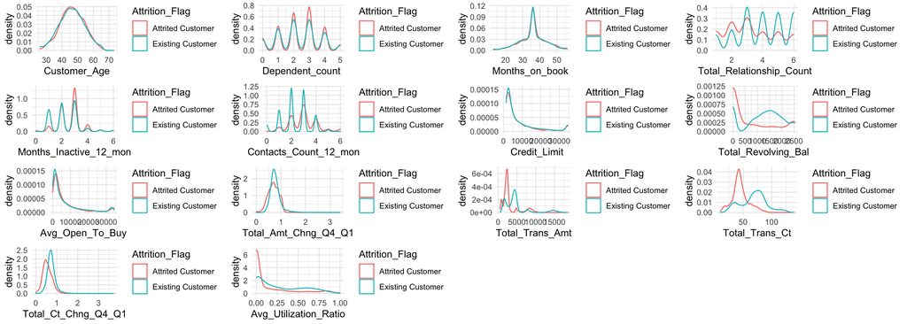

```r
p1 <- df %>%
  ggplot() +
  geom_density(aes(x = Customer_Age, col = Attrition_Flag)) +
  theme_minimal()

p2 <- df %>%
  ggplot() +
  geom_density(aes(x = Dependent_count, col = Attrition_Flag)) +
  theme_minimal()

p3 <- df %>%
  ggplot() +
  geom_density(aes(x = Months_on_book, col = Attrition_Flag)) +
  theme_minimal()

p4 <- df %>%
  ggplot() +
  geom_density(aes(x = Total_Relationship_Count, col = Attrition_Flag)) +
  theme_minimal()

p5 <- df %>%
  ggplot() +
  geom_density(aes(x = Months_Inactive_12_mon, col = Attrition_Flag)) +
  theme_minimal()

p6 <- df %>%
  ggplot() +
  geom_density(aes(x = Contacts_Count_12_mon, col = Attrition_Flag)) +
  theme_minimal()

p7 <- df %>%
  ggplot() +
  geom_density(aes(x = Credit_Limit, col = Attrition_Flag)) +
  theme_minimal()

p8 <- df %>%
  ggplot() +
  geom_density(aes(x = Total_Revolving_Bal, col = Attrition_Flag)) +
  theme_minimal()

p9 <- df %>%
  ggplot() +
  geom_density(aes(x = Avg_Open_To_Buy, col = Attrition_Flag)) +
  theme_minimal()

p10 <- df %>%
  ggplot() +
  geom_density(aes(x = Total_Amt_Chng_Q4_Q1, col = Attrition_Flag)) +
  theme_minimal()

p11 <- df %>%
  ggplot() +
  geom_density(aes(x = Total_Trans_Amt, col = Attrition_Flag)) +
  theme_minimal()

p12 <- df %>%
  ggplot() +
  geom_density(aes(x = Total_Trans_Ct, col = Attrition_Flag)) +
  theme_minimal()

p13 <- df %>%
  ggplot() +
  geom_density(aes(x = Total_Ct_Chng_Q4_Q1, col = Attrition_Flag)) +
  theme_minimal()

p14 <- df %>%
  ggplot() +
  geom_density(aes(x = Avg_Utilization_Ratio, col = Attrition_Flag)) +
  theme_minimal()

grid.arrange(p1, p2, p3, p4, p5, p6, p7, p8, p9, p10, p11, p12, p13, p14, nrow = 4)
```

# Bivariate

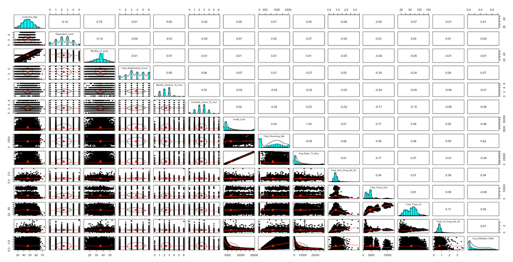

```r
df %>%
    select(-where(is.character), -CLIENTNUM) %>%
    pairs.panels()
```

The figure also shows much weak linear connection between continuous variables in dataset. Another highlight can be taken from the figure: age and number of dependent persons curve is an upside-down U that peaks around middle age, meaning that the sample’s oldest and youngest customers have fewer dependent persons than those in their forties and fifties. Because this tendency is non-linear, the correlations alone could not have led to this conclusion. Similarly, there are other non-linear relationships despite small correlation, such as Total_Amt_Chng_Q4_Q1 and Total_Trans_Amt, Total_Amt_Chng_Q4_Q1 and Total_Trans_Ct.

We next to use the [ANOVA test](http://www.sthda.com/english/wiki/one-way-anova-test-in-r) to consider the discrimination power of each or continuous variables in terms of `Attrition_Flag`. The null is that the means of the different groups are the same.

```r
dat <- data.frame(Variable = character(),F = numeric(), PVal = numeric())
for (name in names(df %>% select(-where(is.character), -CLIENTNUM))){
  aovTest <- tidy(aov(df[[name]] ~ df$Attrition_Flag))
  dat <- rbind(dat, data.frame(Variable = name, F = round(aovTest$statistic,4), PVal = round(aovTest$p.value, 4)))
}
dat <- na.omit(dat)
DT::datatable(dat, rownames = FALSE)
```

| Variable | F | PVal |
| --- | --- | --- |
| Customer_Age | 3.3561 | 0.067 |
| Dependent_count | 3.6528 | 0.056 |
| Months_on_book | 1.8971 | 0.1684 |
| Total_Relationship_Count | 233.0729 | 0 |
| Months_Inactive_12_mon | 240.9104 | 0 |
| Contacts_Count_12_mon | 441.8681 | 0 |
| Credit_Limit | 5.7737 | 0.0163 |
| Total_Revolving_Bal | 752.7024 | 0 |
| Avg_Open_To_Buy | 0.0008 | 0.9771 |
| Total_Amt_Chng_Q4_Q1 | 176.9616 | 0 |

[output cut: 4 more lines]

As can be seen, the null is rejected at 0.05 significance level for `Total_Relationship_Count`, `Months_Inactive_12_mon`, `Contacts_Count_12_mon`, `Credit_Limit`, `Total_Revolving_Bal`, `Total_Amt_Chng_Q4_Q1`, `Total_Trans_Amt`, `Total_Trans_Ct`, `Total_Ct_Chng_Q4_Q1`, `Avg_Utilization_Ratio`. Due to trivial discrimination power of `Avg_Open_To_Buy`, we exclude it and at the same time solving the problem perfect correltion with `Credit_Limit` which significantly contributes to discriminating `Attrition_Flag`.

# Multivariate: [PCA for mixed data](https://arxiv.org/pdf/1411.4911.pdf)

```r
df1 <- df %>%
  mutate_if(is.character, as.factor)
df.quanti <- df1 %>% select(-where(is.factor), -CLIENTNUM) %>% mutate_all(as.numeric) %>% as.data.frame()
df.quali <- df1 %>% select(where(is.factor),-Attrition_Flag) %>% as.data.frame()
pca <- PCAmix(X.quanti = scale(df.quanti), X.quali = df.quali, rename.level = TRUE,graph=FALSE)
DT::datatable(pca$eig)
```

|  | Eigenvalue | Proportion | Cumulative |
| --- | --- | --- | --- |
| dim 1 | 3.45888743931437 | 10.8090232478574 | 10.8090232478574 |
| dim 2 | 2.15155809143461 | 6.72361903573314 | 17.5326422835906 |
| dim 3 | 1.82201353912104 | 5.69379230975325 | 23.2264345933438 |
| dim 4 | 1.62310920947254 | 5.07221627960168 | 28.2986508729455 |
| dim 5 | 1.33173617368114 | 4.16167554275355 | 32.460326415699 |
| dim 6 | 1.2753159729217 | 3.98536241538032 | 36.4456888310794 |
| dim 7 | 1.06748232327209 | 3.33588226022528 | 39.7815710913046 |
| dim 8 | 1.05218287365257 | 3.28807148016429 | 43.0696425714689 |
| dim 9 | 1.04688383673445 | 3.27151198979514 | 46.3411545612641 |
| dim 10 | 1.03451532467243 | 3.23286038960133 | 49.5740149508654 |

[output cut: 21 more lines]

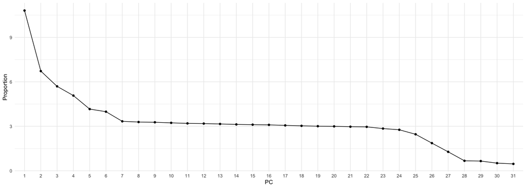

```r
pca$eig %>%
  as_tibble() %>%
  mutate(PC = 1:31) %>%
  ggplot(aes(x = as.factor(PC), y = Proportion, group = 1)) +
  geom_line() +
  geom_point() +
  theme_minimal() +
  xlab('PC')
```

We can see with Factor analysis of mixed data, we need 17 principal components to describe 71.5% of total variation of the dataset, according to the suggestion of Jolliffe (1972). With Kaiser (1958) approach, we need 14 principal components with eigenvalue larger than 1, making up around 62.2% total variation. Scree plot suggests 2 points of elbow, .i.e 7 principal components with 39.8% total variation and 28 principal components with 98.4% total variation. This study selects 17 components for further analyses.

```r
par(mfrow=c(2,2))
plot(pca, choice = "ind", coloring.ind = df.quali$Income_Category,label = FALSE, posleg="bottomright", main="(a) Observations")
plot(pca,choice="levels", main="(b) Levels")
plot(pca,choice="cor",main="(c) Numerical variables")
plot(pca,choice="sqload",coloring.var=T, leg=TRUE,
posleg="topright", main="(d) All variables")
par(mfrow=c(1,1))
```

[figure not shown]

Figure (a) shows the principal component map where customers are colored by their income level. The first dimension (left hand side) highlights observations with low income level (<$60K). Figure (b) confirms this interpretation and suggests that customers with a low income status have usually female. The correlation circle in Figure (c) confirms that `Credit_Limit` is negatively correlated with `Avg_Utilization_Ratio` (recall Pearson correlation -0.48) and that these two variables discriminate the municipalities on the first dimension.

Figure (d) plots the variables (categorical or numerical) using squared loadings as coordinates. For numerical variables, squared loadings are squared correlations and for categorical variables squared loadings are correlation ratios. In both cases, they measure the link between the variables and the principal components. One observes that the 3 numerical variables `Credit_Limit` and `Avg_Open_To_Buy` and `Avg_Utilization_Ratio` and the two categorical variables `Gender` and `Income_Category` are linked to the first component. On the contrary, the variables `Total_Trans_Ct` and `Total_Trans_Amt` are almost orthogonal to these variables and associated to the second component.

For better interpret each components, looking at squared loadings after varimax rotation.

```r
pca <- PCAmix(X.quanti = scale(df.quanti), X.quali = df.quali, rename.level = TRUE, ndim = 20,graph=FALSE)
pcarot <- PCArot(pca,dim=17,graph=FALSE)
cutoff <- function(v, cutoffval = 0.4) {
  ifelse(v >= cutoffval, v, NA)
}
dat <- round(pcarot$sqload %>% as_tibble() %>% mutate_all(cutoff),2) %>% as.data.frame()
rownames(dat) <- rownames(pcarot$sqload)
DT::datatable(dat, options = list(scrollX = TRUE))
```

|  | dim1.rot | dim2.rot | dim3.rot | dim4.rot | dim5.rot | dim6.rot | dim7.rot | dim8.rot | dim9.rot | dim10.rot | dim11.rot | dim12.rot | dim13.rot | dim14.rot | dim15.rot | dim16.rot | dim17.rot |
| --- | --- | --- | --- | --- | --- | --- | --- | --- | --- | --- | --- | --- | --- | --- | --- | --- | --- |
| Customer_Age |  |  | 0.88 |  |  |  |  |  |  |  |  |  |  |  |  |  |  |
| Dependent_count |  |  |  |  |  |  | 0.41 |  |  |  |  |  |  |  |  |  |  |
| Months_on_book |  |  | 0.87 |  |  |  |  |  |  |  |  |  |  |  |  |  |  |
| Total_Relationship_Count |  |  |  |  |  |  |  |  |  |  |  |  |  |  |  |  |  |
| Months_Inactive_12_mon |  |  |  |  |  |  |  |  |  |  |  |  |  |  |  |  |  |
| Contacts_Count_12_mon |  |  |  |  |  |  |  |  |  |  |  |  |  |  |  |  |  |
| Credit_Limit | 0.88 |  |  |  |  |  |  |  |  |  |  |  |  |  |  |  |  |
| Total_Revolving_Bal |  |  |  | 0.88 |  |  |  |  |  |  |  |  |  |  |  |  |  |
| Avg_Open_To_Buy | 0.87 |  |  |  |  |  |  |  |  |  |  |  |  |  |  |  |  |
| Total_Amt_Chng_Q4_Q1 |  |  |  |  | 0.66 |  |  |  |  |  |  |  |  |  |  |  |  |

[output cut: 9 more lines]